# Análise SIM - DOENÇAS CARDIACAS

Rodrigo Silva (r_ds at hotmail.com)

09 de Julho de 2018

Este estudo faz parte da avaliação da propenção de Agravos relacionados à doenças Cardiacas no Brasil, assim está sendo avaliado os dados de Mortalidade (esta análise), casos Ambulatoriais e Hospitalares, bem como os profissionais de saúde Médicos Cardiologistas.

Este estudo pretende entender como se relacionam os casos de doenças cardiacas e a disponibilidade dos profissionais de saúde, bem como enxegar se a presença de cardiologistas auxilia de fato na redução de casos, ou seja, se a população se torna de mais saudável e cuida melhor da sua saúde, ou se é necessário alterarmos as politicas públicas atuais referentes às causalidades de cardiopatias.

Neste estudo iremos avaliar os casos de mortalidade relacionadas às doenças cardícas que, hoje, corresponde ao **Capítulo IX - Doenças do aparelho circulatório (I00-I99)** da CID 10. Entretanto, como podem reparar pelo próprio título, trata-se do capítulo de doenças do aparelho circulatório, o que envolve também outras áreas da medicina além da Cardiologia, desta forma separamos os grupos de doenças deste capítulo por especialidades médicas após um estudo investigativo sobre cada uma das doenças.

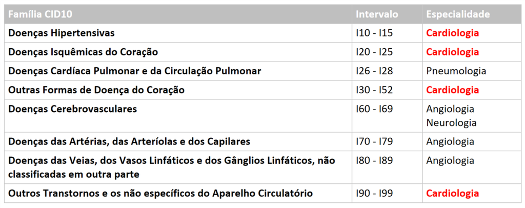

Uma vez com os resultados postos pela tabela acima, iremos apenas investigar as doenças dos primeiro, segundo, quarto e último grupo, como está em destaque a palavra **Cardiologia**.

A estrategia a ser abordada será refinar as entradas a partir das entradas que iniciem com a letra **I** e em um segundo momento fazer um novo refinamento com os intervalos desejados numericamente.

# 1. Avaliação de Caso de Estudo

Vamos pegar apenas um arquivo e construir a avaliação em cima dele, uma vez validado os processos refazemos com todo o conjundo de dados disponível.

Definindo o caminho dos dados:

```r
path_data <- "D:\\SIM"
```

Carregando a biblioteca necessária para os arquivos:

```r
library(read.dbc)
library(dplyr)
library(future.apply)
```

Obtendo um arquivo para desenvolvimento dos testes e avaliação:

```r
setwd(path_data)
dados <- read.dbc("DORN2011.dbc")
```

Visualizando a estrutura dos dados:

```r
str(dados)
```

```
'data.frame':   17802 obs. of  66 variables:
 $ NUMERODO  : Factor w/ 17802 levels "04042523","04042524",..: 1 2 3 4 5 6 7 20 21 22 ...
 $ CODINST   : Factor w/ 152 levels "EDF5300100001",..: 133 133 133 133 110 110 92 100 100 101 ...
 $ ORIGEM    : Factor w/ 1 level "1": 1 1 1 1 1 1 1 1 1 1 ...
 $ NUMERODV  : Factor w/ 10 levels "0","1","2","3",..: NA NA NA NA NA NA NA NA NA NA ...
 $ TIPOBITO  : Factor w/ 1 level "2": 1 1 1 1 1 1 1 1 1 1 ...
 $ DTOBITO   : Factor w/ 365 levels "01012011","01022011",..: 189 26 355 250 308 53 29 336 336 161 ...
 $ HORAOBITO : Factor w/ 843 levels "0000","0001",..: 490 382 772 354 249 764 NA 184 566 658 ...
 $ NATURAL   : Factor w/ 33 levels "125","129","141",..: NA NA NA NA NA 20 NA NA NA NA ...
 $ NUMSUS    : Factor w/ 976 levels "00000000000000",..: NA NA NA NA NA NA NA NA NA NA ...
 $ DTNASC    : Factor w/ 12690 levels "01011907","01011913",..: 11710 3939 8891 1244 10954 1910 10538 4110 6227 88 ...
 $ IDADE     : Factor w/ 193 levels "001","003","005",..: 123 138 101 160 27 24 128 169 153 136 ...
 $ SEXO      : Factor w/ 3 levels "1","2","9": 1 2 1 1 2 2 2 2 1 2 ...
 $ RACACOR   : Factor w/ 5 levels "1","2","3","4",..: 1 1 4 1 NA 4 4 4 1 1 ...
 $ ESTCIV    : Factor w/ 6 levels "1","2","3","4",..: 5 1 1 2 NA NA 3 3 2 2 ...
```

[output cut: 53 more lines]

Lista das variáveis a serem consideradas:

1. IDADE
2. SEXO
3. RACACOR
4. ESC
5. ESTCIV
6. CODMUNRES
7. LOCOCOR
8. CAUSABAS
9. DTOBITO

Criando uma função de filtro para as variáveis acima considerando apenas as mortes do Capítulo IX da CID10 como exposto anteriormente:

Primeiro, precisamos converter a coluna **CAUSABAS** em String:

```r
dados$CAUSABAS <- as.character(dados$CAUSABAS)
```

```r
reduced <- dados %>%
  select('IDADE','SEXO','RACACOR', 'ESC', 'ESTCIV','CODMUNRES', 'LOCOCOR', 'CAUSABAS', 'DTOBITO') %>%
  filter(startsWith(CAUSABAS, "I"))
reduced <- droplevels(reduced)
str(reduced)
```

```
'data.frame':   5203 obs. of  9 variables:
 $ IDADE    : Factor w/ 106 levels "301","304","307",..: 38 75 43 84 68 92 72 82 56 77 ...
 $ SEXO     : Factor w/ 3 levels "1","2","9": 1 1 2 2 1 2 1 1 1 2 ...
 $ RACACOR  : Factor w/ 5 levels "1","2","3","4",..: 1 1 4 4 1 1 1 1 4 1 ...
 $ ESC      : Factor w/ 7 levels "0","1","2","3",..: 2 3 NA 2 3 2 3 2 2 3 ...
 $ ESTCIV   : Factor w/ 6 levels "1","2","3","4",..: 5 2 3 3 2 3 1 3 2 3 ...
 $ CODMUNRES: Factor w/ 167 levels "240000","240010",..: 160 160 90 101 101 161 161 161 103 94 ...
 $ LOCOCOR  : Factor w/ 6 levels "1","2","3","4",..: 1 1 6 1 1 3 3 1 1 3 ...
 $ CAUSABAS : chr  "I219" "I500" "I64" "I500" ...
 $ DTOBITO  : Factor w/ 365 levels "01012011","01022011",..: 189 250 29 336 336 232 246 240 247 265 ...
 - attr(*, "data_types")= chr  "C" "C" "C" "C" ...
```

Uma vez que não precisamos de cada informação especifica das doenças, iremos manter apenas os primeiros 3 caracteres da CID utilizada, removendo o quarto caracter quando este existir:

```r
reduced$CAUSABAS <- substr(reduced$CAUSABAS, 1, 3)
```

Verificando como ficaram os dados:

```r
str(reduced)
```

```
'data.frame':   5203 obs. of  9 variables:
 $ IDADE    : Factor w/ 106 levels "301","304","307",..: 38 75 43 84 68 92 72 82 56 77 ...
 $ SEXO     : Factor w/ 3 levels "1","2","9": 1 1 2 2 1 2 1 1 1 2 ...
 $ RACACOR  : Factor w/ 5 levels "1","2","3","4",..: 1 1 4 4 1 1 1 1 4 1 ...
 $ ESC      : Factor w/ 7 levels "0","1","2","3",..: 2 3 NA 2 3 2 3 2 2 3 ...
 $ ESTCIV   : Factor w/ 6 levels "1","2","3","4",..: 5 2 3 3 2 3 1 3 2 3 ...
 $ CODMUNRES: Factor w/ 167 levels "240000","240010",..: 160 160 90 101 101 161 161 161 103 94 ...
 $ LOCOCOR  : Factor w/ 6 levels "1","2","3","4",..: 1 1 6 1 1 3 3 1 1 3 ...
 $ CAUSABAS : chr  "I21" "I50" "I64" "I50" ...
 $ DTOBITO  : Factor w/ 365 levels "01012011","01022011",..: 189 250 29 336 336 232 246 240 247 265 ...
 - attr(*, "data_types")= chr  "C" "C" "C" "C" ...
```

Agora é necessário filtrar as causas de morte conforme o quadro apresentado acima:

```r
grupoCID = function(dado){
  subgrupo <- as.numeric(substr(dado, 2, 3))

  if (between(subgrupo, 10, 15)) {
    return("Doenças Hipertensivas")
  } else if (between(subgrupo, 20, 25)) {
      return("Doenças Isquêmicas do Coração")
  } else if (between(subgrupo, 30, 52)) {
      return("Outras Formas de Doença do Coração")
  } else if (between(subgrupo, 90, 99)) {
      return("Casos não Específicos do Aparelho Circulatório")
  } else {
      return ("Outros")
    }
}
```

Criaremos uma nova coluna com as informações referentes ao agrupamento da doença:

```r
#reduced <- reduced %>%
#  mutate(GRUPO = grupoCID(CAUSABAS))
reduced$GRUPO <- sapply(reduced$CAUSABAS, grupoCID)
```

Vendo como ficou:

```r
str(reduced)
```

```
'data.frame':   5203 obs. of  10 variables:
 $ IDADE    : Factor w/ 106 levels "301","304","307",..: 38 75 43 84 68 92 72 82 56 77 ...
 $ SEXO     : Factor w/ 3 levels "1","2","9": 1 1 2 2 1 2 1 1 1 2 ...
 $ RACACOR  : Factor w/ 5 levels "1","2","3","4",..: 1 1 4 4 1 1 1 1 4 1 ...
 $ ESC      : Factor w/ 7 levels "0","1","2","3",..: 2 3 NA 2 3 2 3 2 2 3 ...
 $ ESTCIV   : Factor w/ 6 levels "1","2","3","4",..: 5 2 3 3 2 3 1 3 2 3 ...
 $ CODMUNRES: Factor w/ 167 levels "240000","240010",..: 160 160 90 101 101 161 161 161 103 94 ...
 $ LOCOCOR  : Factor w/ 6 levels "1","2","3","4",..: 1 1 6 1 1 3 3 1 1 3 ...
 $ CAUSABAS : chr  "I21" "I50" "I64" "I50" ...
 $ DTOBITO  : Factor w/ 365 levels "01012011","01022011",..: 189 250 29 336 336 232 246 240 247 265 ...
 $ GRUPO    : chr  "Doenças Isquêmicas do Coração" "Outras Formas de Doença do Coração" "Outros" "Outras Formas de Doença do Coração" ...
```

Visualizando como ficou a distribuição das variavéis:

```r
summary(reduced)
```

```
     IDADE      SEXO     RACACOR          ESC        ESTCIV       CODMUNRES    LOCOCOR
 486    : 175   1:2753   1   :2042   1      :1859   1   :1124   240810 :1272   1:3078
 481    : 164   2:2449   2   : 321   2      :1116   2   :2010   240800 : 310   2:  53
 487    : 160   9:   1   3   :  13   0      : 603   3   :1306   240325 : 228   3:1870
 485    : 159            4   :2157   3      : 579   4   : 130   241200 : 136   4:  70
 483    : 153            5   :   3   9      : 357   5   :  56   240260 : 118   5: 115
 476    : 142            NA's: 667   (Other): 418   9   : 113   240710 : 115   9:  17
 (Other):4250                        NA's   : 271   NA's: 464   (Other):3024
   CAUSABAS             DTOBITO        GRUPO
 Length:5203        10072011:  25   Length:5203
 Class :character   21072011:  25   Class :character
 Mode  :character   24042011:  25   Mode  :character
                    18102011:  24
                    09062011:  23
                    12092011:  23
                    (Other) :5058
```

```r
grupos <- as.data.frame(table(reduced$GRUPO))
head(grupos)
```

|  | Var1 | Freq |
| --- | --- | --- |
| 1 | Casos não Específicos do Aparelho Circulatório | 4 |
| 2 | Doenças Hipertensivas | 856 |
| 3 | Doenças Isquêmicas do Coração | 1875 |
| 4 | Outras Formas de Doença do Coração | 767 |
| 5 | Outros | 1701 |

# 2. Funções para Análise

## 2.1. Função de Classificação por Grupo de CID

```r
grupoCID = function(dado){
  subgrupo <- as.numeric(substr(dado, 2, 3))

  if (between(subgrupo, 10, 15)) {
    return("Doenças Hipertensivas")
  } else if (between(subgrupo, 20, 25)) {
      return("Doenças Isquêmicas do Coração")
  } else if (between(subgrupo, 30, 52)) {
      return("Outras Formas de Doença do Coração")
  } else if (between(subgrupo, 90, 99)) {
      return("Casos não Específicos do Aparelho Circulatório")
  } else {
      return ("Outros")
    }
}
```

## 2.2. Função de Redução

```r
reduce = function(data){
  data$CAUSABAS <- as.character(data$CAUSABAS)

  tmp <- data %>%
  select('IDADE','SEXO','RACACOR', 'ESC', 'ESTCIV','CODMUNRES', 'LOCOCOR', 'CAUSABAS', 'DTOBITO') %>%
  filter(startsWith(CAUSABAS, "I"))

  tmp$CAUSABAS <- substr(tmp$CAUSABAS, 1, 3)

  tmp <- droplevels(tmp)

  tmp$GRUPO <- sapply(tmp$CAUSABAS, grupoCID)

  return(tmp)
}
```

## 2.3. Abrir os arquivos DBCs

```r
readDBC = function(file){

  setwd(path_data)

  tmp <- read.dbc(file)

  res <- reduce(tmp)

  res <- droplevels(res)

  return(res)
}
```

# 3. Testando Paralelismo

Detectando quantos cores existem disponíveis no pc

```r
parallel::detectCores()
```

```
[1] 4
```

Testando a leitura dos arquivos

```r
listoffiles <- list.files(path_data, pattern = "DO")
plan(multiprocess, workers = 2) ## Parallelize using 2 cores
result <- do.call(rbind, future_lapply(listoffiles, readDBC))
str(result)
```

```
'data.frame':   6995450 obs. of  10 variables:
 $ IDADE    : Factor w/ 256 levels "101","102","103",..: 83 NA 125 128 94 108 91 137 98 126 ...
 $ SEXO     : Factor w/ 4 levels "1","2","0","9": 1 1 2 1 1 2 2 1 1 2 ...
 $ RACACOR  : Factor w/ 7 levels "1","3","2","4",..: NA NA NA NA NA NA NA NA NA NA ...
 $ ESC      : Factor w/ 9 levels "1","5","8","9",..: NA NA NA NA NA NA NA NA NA NA ...
 $ ESTCIV   : Factor w/ 10 levels "1","2","3","4",..: 1 NA 3 2 1 2 NA 3 2 3 ...
 $ CODMUNRES: Factor w/ 11231 levels "1200000","1200013",..: 16 16 16 16 16 16 16 16 14 16 ...
 $ LOCOCOR  : Factor w/ 8 levels "1","3","4","5",..: 3 1 1 1 1 2 1 2 1 1 ...
 $ CAUSABAS : chr  "I21" "I50" "I69" "I21" ...
 $ DTOBITO  : Factor w/ 7731 levels "01011996","01021996",..: 42 13 13 25 73 85 133 133 145 133 ...
 $ GRUPO    : chr  "Doenças Isquêmicas do Coração" "Outras Formas de Doença do Coração" "Outros" "Doenças Isquêmicas do Coração" ...
 - attr(*, "data_types")= chr  "C" "C" "C" "C" ...
```

```r
# res <- data.frame()
#
# cl <- parallel::makeCluster(2)
# doParallel::registerDoParallel(cl)
# tryCatch(readDBC(listoffiles), error = function(e) print(e))
#
# str(res)
```

```r
length(listoffiles)
```

```
[1] 569
```

```r
gc()
```

```
           used  (Mb) gc trigger  (Mb) max used  (Mb)
Ncells  1632418  87.2    3162497 168.9  3162497 168.9
Vcells 46398829 354.0   70110077 534.9 58308283 444.9
```

Sumarisando os dados para avaliarmos:

```r
summary(result)
```

```
     IDADE           SEXO            RACACOR             ESC              ESTCIV          CODMUNRES          LOCOCOR
 477    : 190073   1   :3671726   1      :3635227   2      :1436014   2      :2817208   355030 : 302465   1      :4697746
 476    : 190066   2   :3321810   4      :1856481   1      :1321151   3      :2005632   3550308: 221930   3      :1746666
 478    : 189870   0   :   1614   2      : 525201   9      :1066192   1      :1312415   330455 : 203203   2      : 270074
 479    : 189793   9   :     62   3      :  54398   3      :1022197   4      : 309576   3304557: 102100   5      : 159428
 480    : 188412   NA's:    238   5      :  10170   4      : 495590   9      : 206912   310620 :  47833   4      :  89806
 (Other):6042791                  (Other):      2   (Other): 370339   (Other):  91709   292740 :  47774   (Other):  24826
 NA's   :   4445                  NA's   : 913971   NA's   :1283967   NA's   : 251998   (Other):6070145   NA's   :   6904
   CAUSABAS             DTOBITO           GRUPO
 Length:6995450     14062016:   2534   Length:6995450
 Class :character   13062016:   2512   Class :character
 Mode  :character   16062016:   2466   Mode  :character
                    17062016:   2398
                    15062016:   2396
                    10072016:   2360
                    (Other) :6980784
```

Tempo consumido no processo:

```r
print("Tempo abrindo os arquivos : ")
```

```
[1] "Tempo abrindo os arquivos : "
```

```r
t2 - t1
```

[output not shown]

```r
print("Tempo fazendo o merge dos dados:")
```

```
[1] "Tempo fazendo o merge dos dados:"
```

```r
t3 - t2
```

[output not shown]

Adicionando a origem

```r
result$BASE <- "SIM"
```

Exportando o resultado final para um arquivo .csv:

```r
setwd("C:\\Users\\r_ds\\Documents\\Estudos\\Mortalidade\\Analises")
write.csv2(result, "mortalidade-cardio.csv",row.names=FALSE)
```